# AIRLINE PASSENGER SATISFACTION

TEAM 7- Richik Ghosh, Shreya Sahay, Sanika Narayanapethkar, Vamsidhar Boddu

2023-11-01

```r
library(ezids)
library(ggplot2)
library(gridExtra)
```

# Importing the Data

```r
data_pre<-data.frame(read.csv("/Users/richikghosh/Documents/Project Dats 6101/Airlines_train.csv"))
data<-data_pre
```

We have read the dataset using `read.csv()` and stored it in a dataframe called `data`.

# Structure of the data

```r
str(data)
```

```
## 'data.frame':    103904 obs. of  25 variables:
##  $ X                                : int  0 1 2 3 4 5 6 7 8 9 ...
##  $ id                               : int  70172 5047 110028 24026 119299 111157 82113 96462 79485 65725 ...
##  $ Gender                           : chr  "Male" "Male" "Female" "Female" ...
##  $ Customer.Type                    : chr  "Loyal Customer" "disloyal Customer" "Loyal Customer" "Loyal Customer" ...
##  $ Age                              : int  13 25 26 25 61 26 47 52 41 20 ...
##  $ Type.of.Travel                   : chr  "Personal Travel" "Business travel" "Business travel" "Business travel" ...
##  $ Class                            : chr  "Eco Plus" "Business" "Business" "Business" ...
##  $ Flight.Distance                  : int  460 235 1142 562 214 1180 1276 2035 853 1061 ...
##  $ Inflight.wifi.service            : int  3 3 2 2 3 3 2 4 1 3 ...
##  $ Departure.Arrival.time.convenient: int  4 2 2 5 3 4 4 3 2 3 ...
##  $ Ease.of.Online.booking           : int  3 3 2 5 3 2 2 4 2 3 ...
##  $ Gate.location                    : int  1 3 2 5 3 1 3 4 2 4 ...
##  $ Food.and.drink                   : int  5 1 5 2 4 1 2 5 4 2 ...
##  $ Online.boarding                  : int  3 3 5 2 5 2 2 5 3 3 ...
##  $ Seat.comfort                     : int  5 1 5 2 5 1 2 5 3 3 ...
##  $ Inflight.entertainment           : int  5 1 5 2 3 1 2 5 1 2 ...
##  $ On.board.service                 : int  4 1 4 2 3 3 3 5 1 2 ...
##  $ Leg.room.service                 : int  3 5 3 5 4 4 3 5 2 3 ...
##  $ Baggage.handling                 : int  4 3 4 3 4 4 4 5 1 4 ...
##  $ Checkin.service                  : int  4 1 4 1 3 4 3 4 4 4 ...
##  $ Inflight.service                 : int  5 4 4 4 3 4 5 5 1 3 ...
##  $ Cleanliness                      : int  5 1 5 2 3 1 2 4 2 2 ...
##  $ Departure.Delay.in.Minutes       : int  25 1 0 11 0 0 9 4 0 0 ...
##  $ Arrival.Delay.in.Minutes         : num  18 6 0 9 0 0 23 0 0 0 ...
##  $ satisfaction                     : chr  "neutral or dissatisfied" "neutral or dissatisfied" "satisfied" "neutral or dissatisfied" ...
```

We used `str()` function to study the structure of the data and further classified the variables into qualitative and quantitative types.

from the help menu, we can see that the variables are: * `id`: customer id

- `Gender`: male or female
- `Customer.Type`: loyal or disloyal
- `Age`: tells us the age in years
- `Type.Of.Travel`: personal or business
- `Class`: business, eco, or eco plus
- `Flight.Distance`: distance in nautical miles
- `Inflight.wifi.service`: rating of wifi service
- `Departure.Arrival.time.convenient`: rating of time convenience
- `Ease.of.Online.booking`: rating of ease of convenience
- `Gate.location`: rating of gate location
- `Food.and.Drink`: rating of food and drink items served in-flight
- `Online.boarding`: rating of boarding convenience
- `Seat.comfort`: rating of comfort
- `Inflight.entertainment`: rating of how well customers were entertained
- `On.board.service`: rating of on-boarding service
- `Leg.room.service`: rating of space availability for legs
- `Baggage.handling`: rating of handling baggage
- `Checkin.service`: rating of check-in experience
- `Inflight.service`: rating of in-flight experience
- `cleanliness`: rating of cleanliness
- `Departure.Delay.in.Minutes`: flight departure delay in minutes
- `Arrival.Delay.in.minutes`: flight arrival delay in minutes
- `satisfaction`: rating of overall experience

**NOTE: All the ratings are on a scale of 0-5**

These variables can be re-classified as:

- Qualitative: `satisfaction`, `Class`, `Type.of.Travel`, `Gender`, `Customer.Type`
- Quantitative: `id`, `Age`, `Flight.Distance`, `Inflight.wifi.service`, `Departure.Arrival.time.convenient`, `Ease.of.Online.booking`, `Gate.location`, `Food.and.Drink`, `Online.boarding`, `Seat.comfort`, `Inflight.entertainment`, `On.board.service`, `Leg.room.service`, `Baggage.handling`, `Checkin.service`, `Inflight.service`, `cleanliness`, `Departure.Delay.in.Minutes`, `Arrival.Delay.in.minutes`.

# Data Preprocessing

## Dropping columns

```r
data<- subset(data_pre, select = -c(X, id))
```

Using the `subset()` function we removed the `id` and `X` columns since they were helpful only for data retrieval/identification and do not contribute much to data analysis.

## Factoring the variables

```r
data$satisfaction<-as.factor(data$satisfaction)
data$Class<-as.factor(data$Class)
data$Type.of.Travel<-as.factor(data$Type.of.Travel)
data$Gender<-as.factor(data$Gender)
data$Customer.Type<-as.factor(data$Customer.Type)
```

We did factoring of the qualitative variables for performing EDA. We converted `satisfaction`, `Class`, `Type.of.Travel`, `Gender` and `Customer.Type`. We use the `as.factor()` function.

## Replacing the NA values with mean

```r
data$Arrival.Delay.in.Minutes[is.na(data$Arrival.Delay.in.Minutes)] = mean(data$Arrival.Delay.in.Minute,na.rm = TRUE)
paste("The NA's in the dataset after Arrival Delay in Minute with mean is:",sum(is.na(data)))
```

```
## [1] "The NA's in the dataset after Arrival Delay in Minute with mean is: 0"
```

## Removal of Outliers

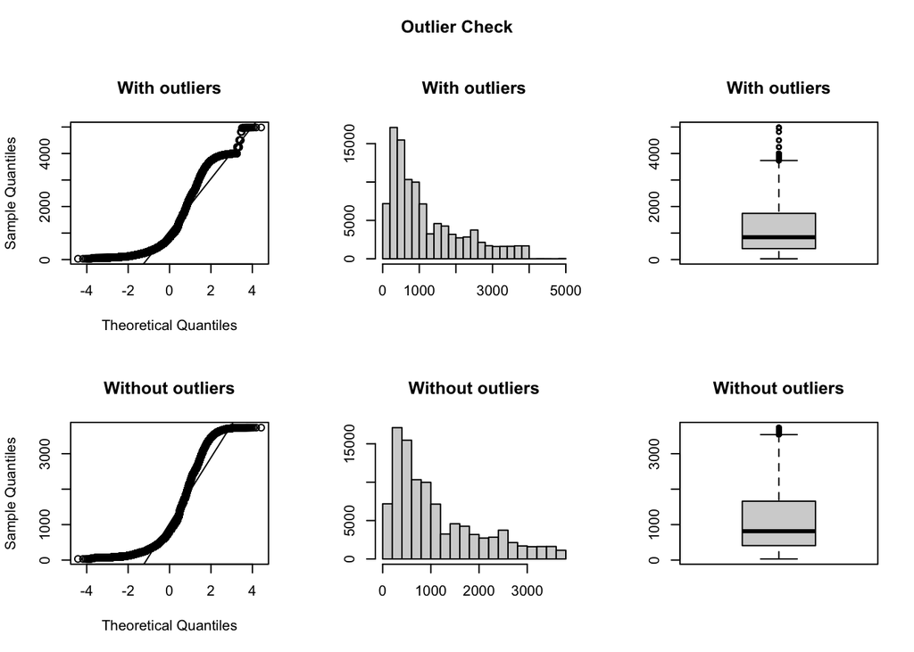

```
## Outliers identified: 2291
## Proportion (%) of outliers: 2.3
## Mean of the outliers: 3887
## Mean without removing outliers: 1189
## Mean if we remove outliers: 1129
## Outliers successfully removed
```

```r
data2<-outlierKD2(data,Flight.Distance,rm=TRUE,boxplt = TRUE,qqplt = TRUE)
```

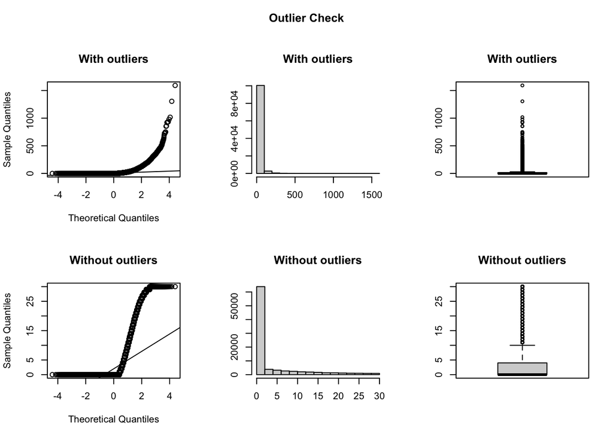

```
## Outliers identified: 14529
## Proportion (%) of outliers: 16.3
## Mean of the outliers: 83.1
## Mean without removing outliers: 14.8
## Mean if we remove outliers: 3.72
## Outliers successfully removed
```

```r
data3<-outlierKD2(data,Departure.Delay.in.Minutes,rm=TRUE,boxplt = TRUE,qqplt = TRUE)
```

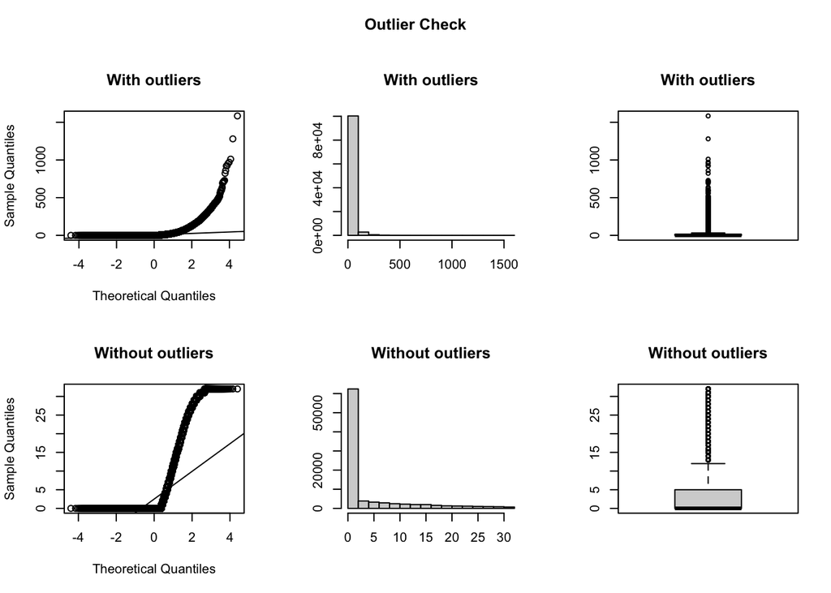

```
## Outliers identified: 13954
## Proportion (%) of outliers: 15.5
## Mean of the outliers: 86.3
## Mean without removing outliers: 15.2
## Mean if we remove outliers: 4.15
## Outliers successfully removed
```

```r
data4<-outlierKD2(data3,Arrival.Delay.in.Minutes,rm=TRUE,boxplt = TRUE,qqplt = TRUE)
```

## Categorization of Age Groups

```r
data <- within(data,{Age.cat = NA
  Age.cat[Age<=20] = "Under 20"
  Age.cat[Age>=21 & Age<= 40 ] = "20-40"
  Age.cat[Age>=41 & Age<= 80 ] = "40-80"
  Age.cat[Age>=80 ] = "above 80"})
data$Age.cat<- factor(data$Age.cat,levels= c("Under 20","20-40","40-80","above 80"))
```

```r
data <- within(data,{Age.cat2 = NA
  Age.cat2[Age<=20] = 1
  Age.cat2[Age>=21 & Age<= 40 ] = 2
  Age.cat2[Age>=41 & Age<= 80 ] = 3
  Age.cat2[Age>=80 ] = 4})
#data$Age.cat2<- factor(data$Age.cat2,levels= c("1","2","3","4"))
```

We created a new categorical variable named `Age.cat` based on the values of the existing `Age` variable. It categorizes individuals into age groups and then converts this new variable into a factor variable with specified levels. `within()` function is used to form new variable within the existing `dataset`.

# Summary of the data

```r
paste("The NA's in the dataset column Arrival.Delay.in.Minutes is:",sum(is.na(data$Arrival.Delay.in.Minutes)))
```

```
## [1] "The NA's in the dataset column Arrival.Delay.in.Minutes is: 0"
```

```r
summary(data)
```

```
##     Gender                Customer.Type        Age
##  Female:52727   disloyal Customer:18981   Min.   : 7.0
##  Male  :51177   Loyal Customer   :84923   1st Qu.:27.0
##                                           Median :40.0
##                                           Mean   :39.4
##                                           3rd Qu.:51.0
##                                           Max.   :85.0
##          Type.of.Travel       Class       Flight.Distance Inflight.wifi.service
##  Business travel:71655   Business:49665   Min.   :  31    Min.   :0.00
##  Personal Travel:32249   Eco     :46745   1st Qu.: 414    1st Qu.:2.00
##                          Eco Plus: 7494   Median : 843    Median :3.00
##                                           Mean   :1189    Mean   :2.73
##                                           3rd Qu.:1743    3rd Qu.:4.00
##                                           Max.   :4983    Max.   :5.00
##  Departure.Arrival.time.convenient Ease.of.Online.booking Gate.location
##  Min.   :0.00                      Min.   :0.00           Min.   :0.00
##  1st Qu.:2.00                      1st Qu.:2.00           1st Qu.:2.00
##  Median :3.00                      Median :3.00           Median :3.00
##  Mean   :3.06                      Mean   :2.76           Mean   :2.98
##  3rd Qu.:4.00                      3rd Qu.:4.00           3rd Qu.:4.00
##  Max.   :5.00                      Max.   :5.00           Max.   :5.00
##  Food.and.drink Online.boarding  Seat.comfort  Inflight.entertainment
##  Min.   :0.0    Min.   :0.00    Min.   :0.00   Min.   :0.00
##  1st Qu.:2.0    1st Qu.:2.00    1st Qu.:2.00   1st Qu.:2.00
##  Median :3.0    Median :3.00    Median :4.00   Median :4.00
##  Mean   :3.2    Mean   :3.25    Mean   :3.44   Mean   :3.36
##  3rd Qu.:4.0    3rd Qu.:4.00    3rd Qu.:5.00   3rd Qu.:4.00
##  Max.   :5.0    Max.   :5.00    Max.   :5.00   Max.   :5.00
##  On.board.service Leg.room.service Baggage.handling Checkin.service
##  Min.   :0.00     Min.   :0.00     Min.   :1.00     Min.   :0.0
##  1st Qu.:2.00     1st Qu.:2.00     1st Qu.:3.00     1st Qu.:3.0
##  Median :4.00     Median :4.00     Median :4.00     Median :3.0
##  Mean   :3.38     Mean   :3.35     Mean   :3.63     Mean   :3.3
##  3rd Qu.:4.00     3rd Qu.:4.00     3rd Qu.:5.00     3rd Qu.:4.0
##  Max.   :5.00     Max.   :5.00     Max.   :5.00     Max.   :5.0
##  Inflight.service  Cleanliness   Departure.Delay.in.Minutes
##  Min.   :0.00     Min.   :0.00   Min.   :   0
##  1st Qu.:3.00     1st Qu.:2.00   1st Qu.:   0
##  Median :4.00     Median :3.00   Median :   0
##  Mean   :3.64     Mean   :3.29   Mean   :  15
##  3rd Qu.:5.00     3rd Qu.:4.00   3rd Qu.:  12
##  Max.   :5.00     Max.   :5.00   Max.   :1592
##  Arrival.Delay.in.Minutes                  satisfaction       Age.cat
##  Min.   :   0             neutral or dissatisfied:58879   Under 20:11333
##  1st Qu.:   0             satisfied              :45025   20-40   :42627
##  Median :   0                                             40-80   :49849
##  Mean   :  15                                             above 80:   95
##  3rd Qu.:  13
##  Max.   :1584
##     Age.cat2
##  Min.   :1.00
##  1st Qu.:2.00
##  Median :2.00
##  Mean   :2.37
##  3rd Qu.:3.00
##  Max.   :4.00
```

These lines of code generate a message that combines a text string with the `count` of `NA values` using the `is.na()` function in the `Arrival.Delay.in.Minutes` variable. The `summary()` function provides a statistical summary of the entire dataset.

# Visualizations

## Age distribution

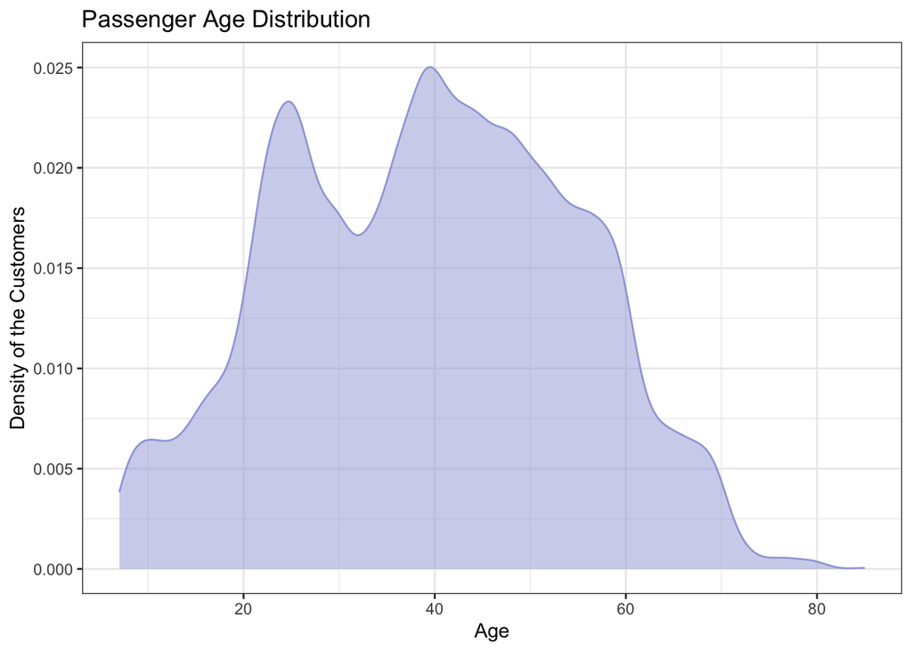

```r
ggplot(data, aes(x=Age)) +  geom_density(fill="#9FA8DA", color="#9FA8DA", alpha=0.5)+ theme_bw() + theme()+ ggtitle("Passenger Age Distribution")+labs(title = "Passenger Age Distribution",
       x = "Age",
       y = "Density of the Customers")
```

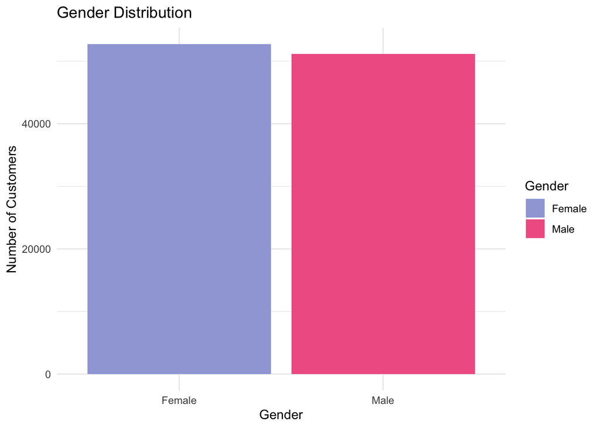

```r
## Gender vs Satisfaction plot using bar plot

gender_1 <- table(data$Gender)
gender_dist <- as.data.frame(gender_1)
names(gender_dist)<-c("Gender","Count")

ggplot(gender_dist, aes(x = Gender, y = Count, fill = Gender)) +
  geom_bar(stat = "identity") +
  labs(title = "Gender Distribution",
       x = "Gender",
       y = "Number of Customers") +
  scale_fill_manual(values = c("Male" = "#F06292", "Female" = "#9FA8DA", "Other" = "gray")) +
  theme_minimal()
```

## Barplot of Satisfaction

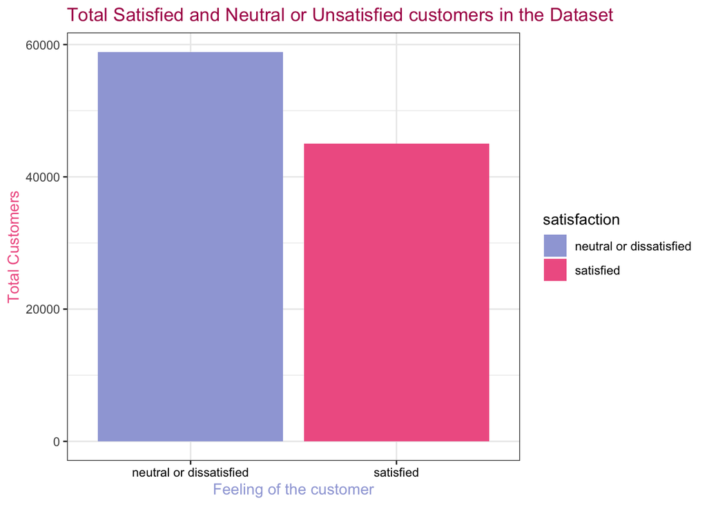

```r
## Overall satisfaction insight of the passengers

ggplot(data, aes(x=satisfaction,fill=satisfaction))+geom_bar()+ggtitle("Total Satisfied and Neutral or Unsatisfied customers in the Dataset")+ theme_bw() +
  theme()+ ylab("Total Customers") + xlab("Feeling of the customer")+ theme(
    axis.title.x = element_text(color = "#9FA8DA"),
    axis.title.y = element_text(color = "#F06292"),
    plot.title = element_text(color = "#AD1457"),
    axis.text.x = element_text(color = "black"))+ scale_fill_manual(values = c("satisfied" = "#F06292", "neutral or dissatisfied" = "#9FA8DA", "Other" = "gray"))
```

## Barplot of dependencies of three varibles on Satisfaction of a customer

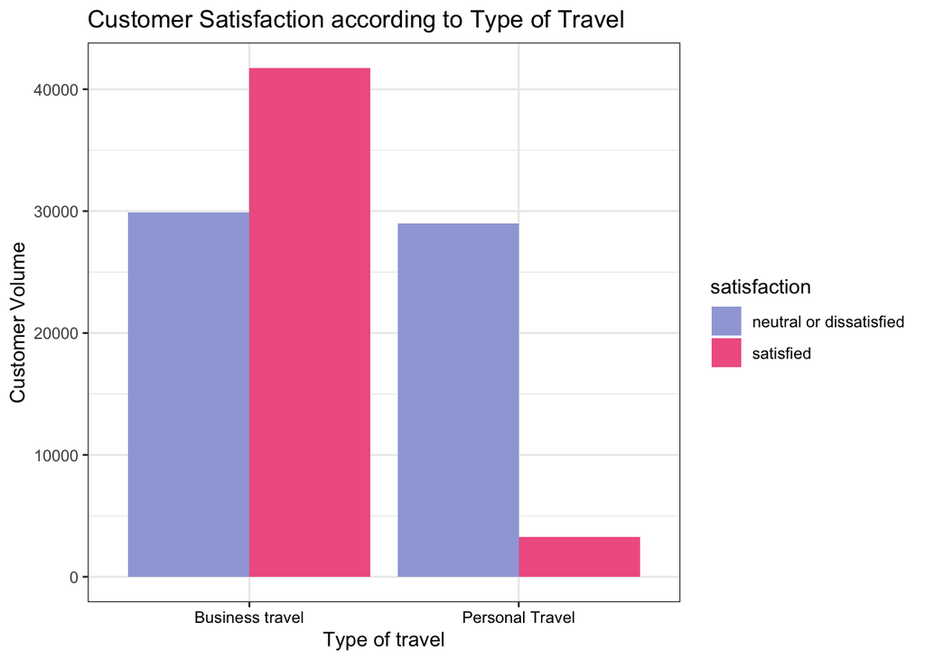

```r
## Type of Travel vs Satisfaction plot using bar plot
ggplot(data, aes(x=Type.of.Travel,fill=satisfaction))+geom_bar(position = "dodge")+ggtitle("Customer Satisfaction according to Type of Travel")+ theme_bw() +
  theme()+ylab("Customer Volume") + xlab("Type of travel")+ theme(
    axis.title.x = element_text(color = "black"),
    axis.title.y = element_text(color = "black"),
    plot.title = element_text(color = "black"),
    axis.text.x = element_text(color = "black"))+ scale_fill_manual(values = c("satisfied" = "#F06292", "neutral or dissatisfied" = "#9FA8DA", "Other" = "gray"))
```

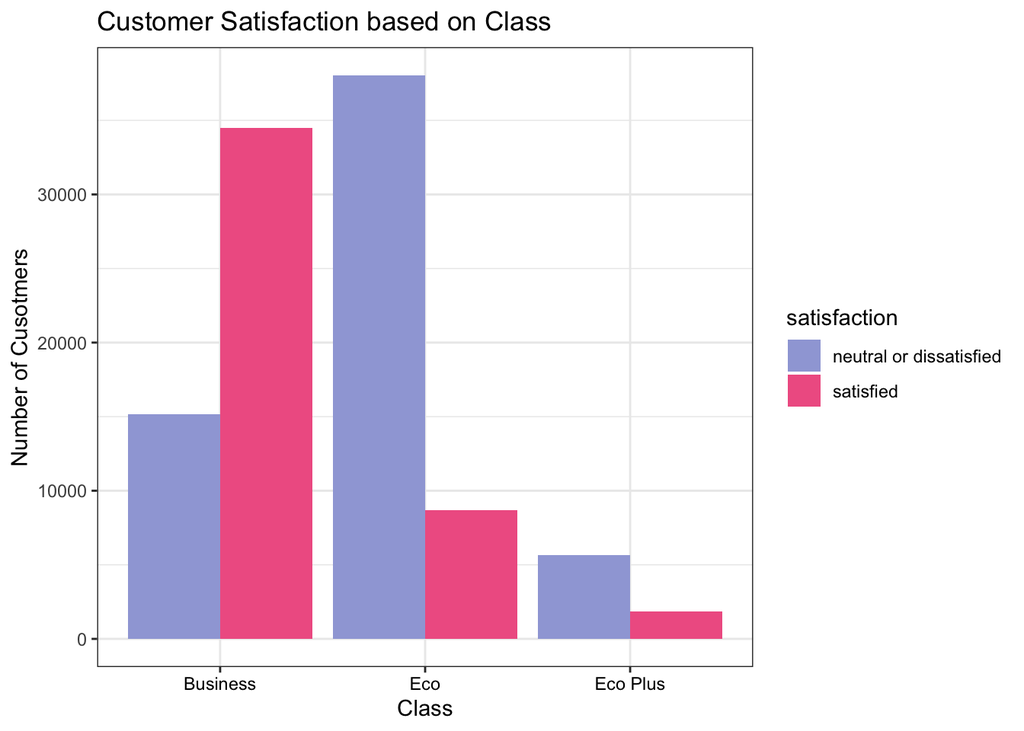

```r
ggplot(data, aes(x=Class,fill=satisfaction))+geom_bar(position = "dodge")+ggtitle("Customer Satisfaction based on Class")+ theme_bw() +
  theme()+ylab("Number of Cusotmers") + xlab("Class")+ theme(
    axis.title.x = element_text(color = "black"),
    axis.title.y = element_text(color = "black"),
    plot.title = element_text(color = "black"),
    axis.text.x = element_text(color = "black"))+ scale_fill_manual(values = c("satisfied" = "#F06292", "neutral or dissatisfied" = "#9FA8DA", "Other" = "gray"))
```

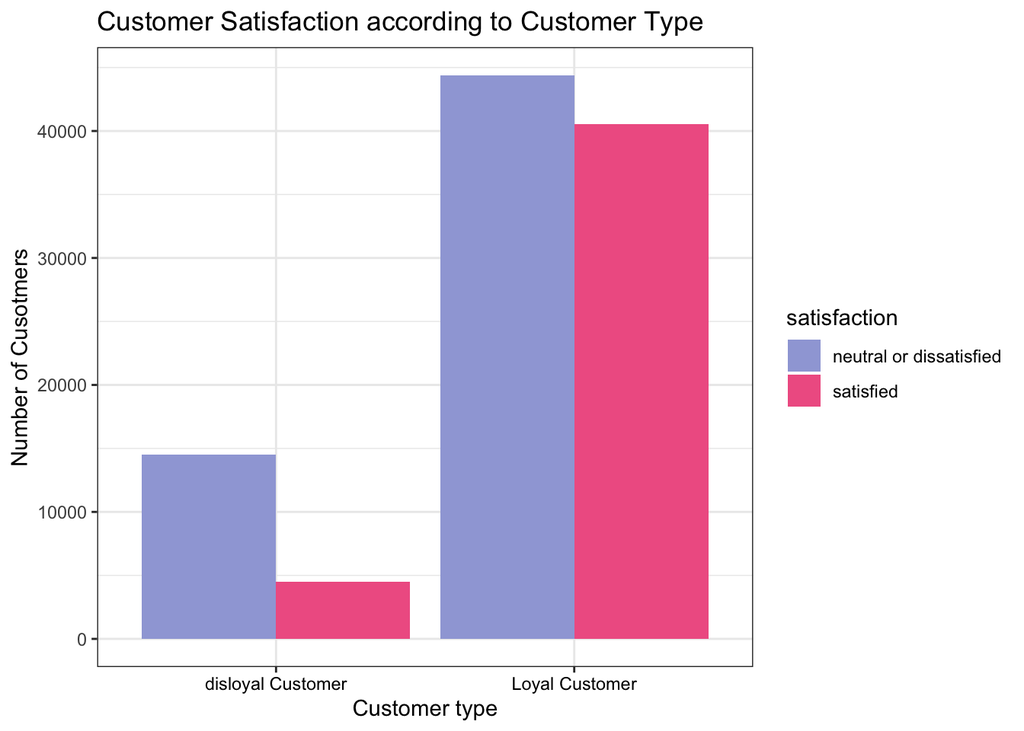

```r
ggplot(data, aes(x=Customer.Type,fill=satisfaction))+geom_bar(position = "dodge")+ggtitle("Customer Satisfaction according to Customer Type")+ylab("Number of Cusotmers") + xlab("Customer type")+theme_bw()+theme(
    axis.title.x = element_text(color = "black"),
    axis.title.y = element_text(color = "black"),
    plot.title = element_text(color = "black"),
    axis.text.x = element_text(color = "black"))+ scale_fill_manual(values = c("satisfied" = "#F06292", "neutral or dissatisfied" = "#9FA8DA", "Other" = "gray"))
```

```r
#grid.arrange(p1, p2, p3, p4, p5)
```

We called the packages `ggplot2` and `gridExtra` using the `library()` function.

We count the frequency of each unique value in the `Gender` column and store this information in the gender_1 table. We use the `as.data.frame()` to convert the tabulated data into a format that’s more suitable for data analysis. `names(gender_dist) <- c("Gender", "Count")` this step is often done to make the data frame more descriptive and easy to work with.

We created a `barplot` using `ggplot()` that visualizes the `Gender` distribution based on the data in the gender_dist data frame. `stat =identity` argument indicates that the heights of the bars should be taken directly from the `Count` column in the data frame.

We created a `barplot` using `ggplot()` that compares `satisfaction` with different `Types.of.Travel` from the `data` data frame.

We created a `barplot` using `ggplot()` that compares `satisfaction` for various `Classes` in the `data` dataset.

We created a `barplot` using `ggplot()` that compares `satisfaction` for various `Customer.Type` in the `data` dataset.

## Barplot of Customer Satisfaction based on different Age Groups

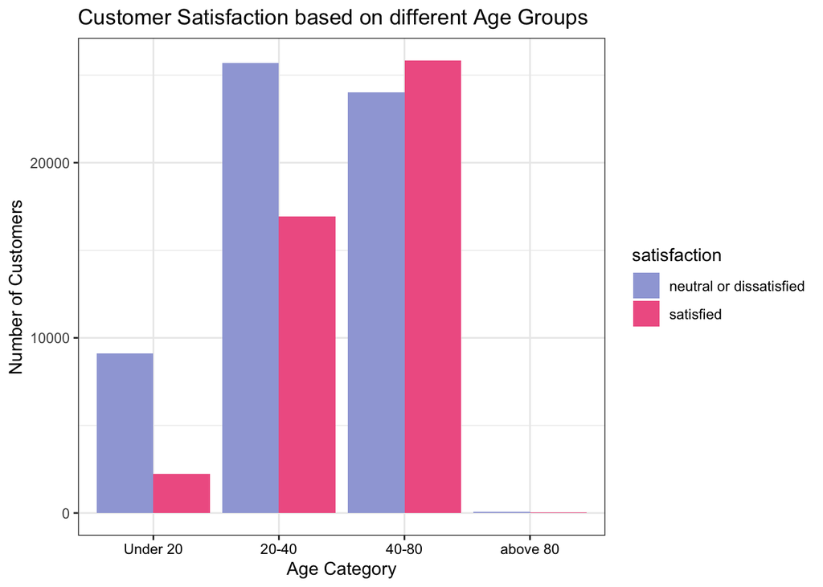

```r
ggplot(data, aes(x=Age.cat,fill=satisfaction))+geom_bar(position = "dodge")+ggtitle("Customer Satisfaction based on different Age Groups")+ylab("Number of Customers") + xlab("Age Category")+theme_bw()+theme(
    axis.title.x = element_text(color = "black"),
    axis.title.y = element_text(color = "black"),
    plot.title = element_text(color = "black"),
    axis.text.x = element_text(color = "black"))+ scale_fill_manual(values = c("satisfied" = "#F06292", "neutral or dissatisfied" = "#9FA8DA", "Other" = "gray"))
```

We created a `barplot` using `ggplot()` that visualizes the `satisfaction` distribution based on the data in the `Age.cat` data frame.

## Boxplot age vs satisfaction of a customer

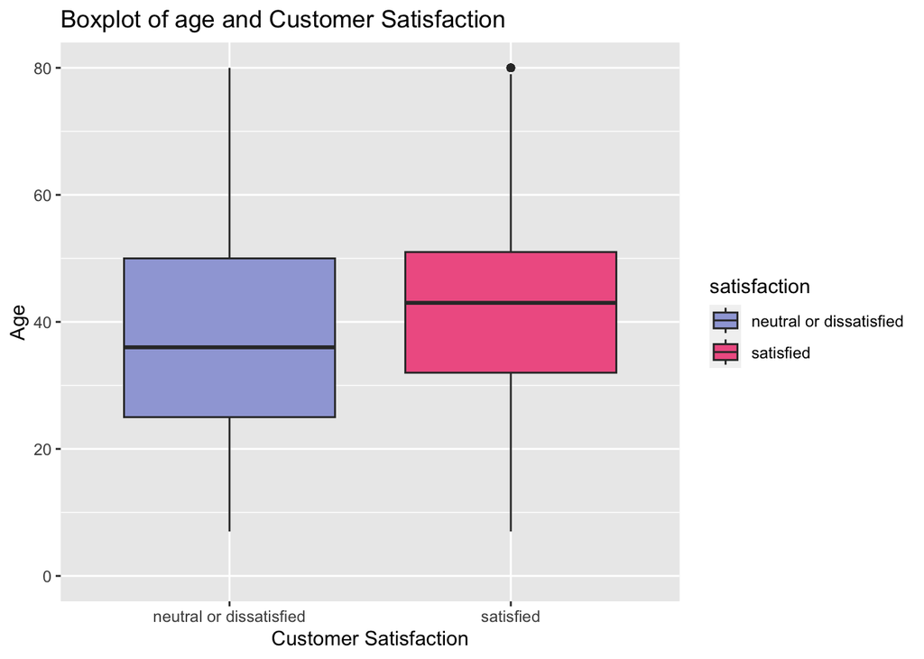

```r
ggplot(data = data, aes(x=as.character(satisfaction ), y=Age, fill=satisfaction)) +
    geom_boxplot() +
    labs(title="Boxplot of age and Customer Satisfaction", x="Customer Satisfaction", y="Age")+ scale_fill_manual(values = c("satisfied" = "#F06292", "neutral or dissatisfied" = "#9FA8DA", "Other" = "gray"))+ scale_y_continuous(limits = c(0, 80))
```

```r
data_sat=subset(data4, data$satisfaction=='satisfied')
data_dissat=subset(data4, data$satisfaction=='neutral or dissatisfied')
```

## Boxplot of departure delay vs satisfaction

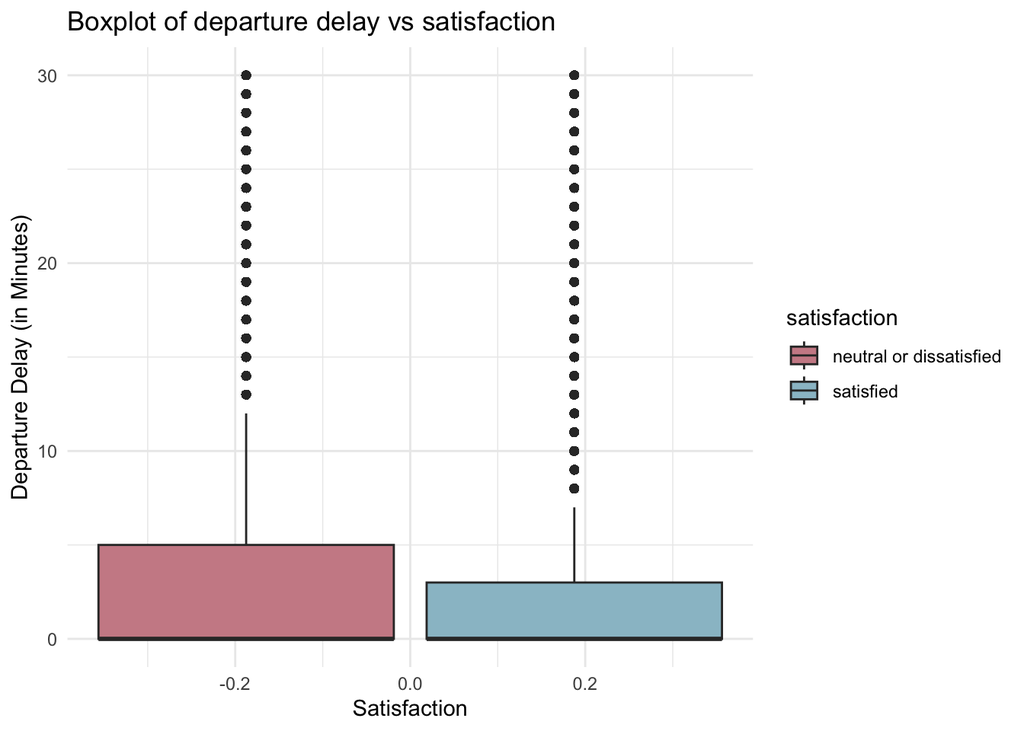

```r
ggplot(data4, aes(y = Departure.Delay.in.Minutes, fill = satisfaction)) +
  geom_boxplot() +
  scale_fill_manual(values = c("satisfied" = "lightblue3", "neutral or dissatisfied" = "lightpink3")) +
  labs(title = "Boxplot of departure delay vs satisfaction",
       x = "Satisfaction", y = "Departure Delay (in Minutes)") +
  theme_minimal()+ scale_y_continuous(limits = c(0, 30))
```

## Boxplot of arrival delay vs satisfaction

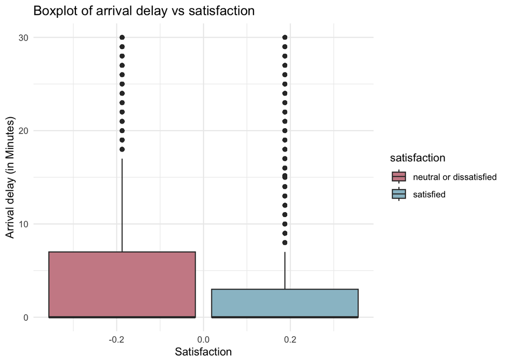

```r
ggplot(data4, aes(y = Arrival.Delay.in.Minutes, fill = satisfaction)) +
  geom_boxplot() +
  scale_fill_manual(values = c("satisfied" = "lightblue3", "neutral or dissatisfied" = "lightpink3")) +
  labs(title = "Boxplot of arrival delay vs satisfaction",
       x = "Satisfaction", y = "Arrival delay (in Minutes)") +
  theme_minimal()+ scale_y_continuous(limits = c(0, 30))
```

We created a `boxplot` using `ggplot()` that compares `satisfaction` with `Age`.

## VIOLIN CHART AND CORREALATION COEFFICIENT

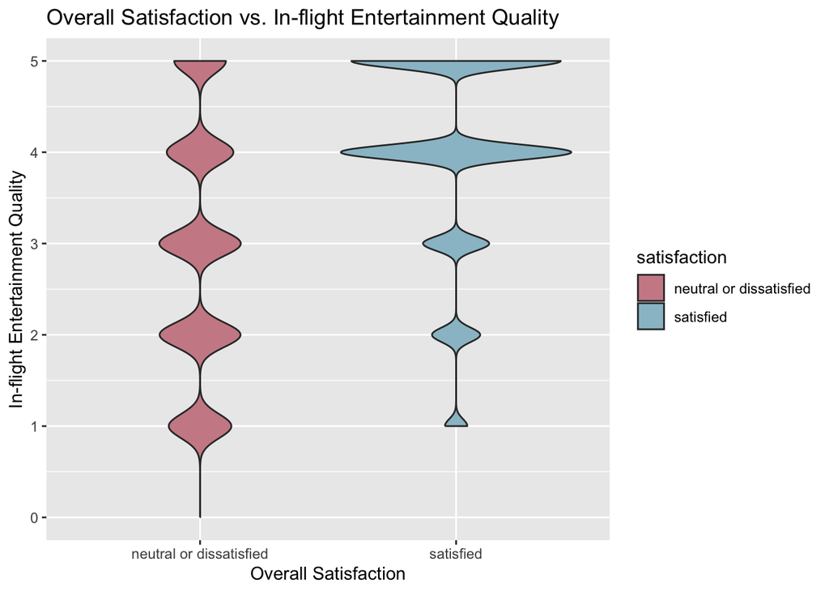

```r
library(ggplot2)

ggplot(data, aes(x = satisfaction, y = Inflight.entertainment, fill = satisfaction)) +
  geom_violin() +
  labs(title = "Overall Satisfaction vs. In-flight Entertainment Quality",
       x = "Overall Satisfaction",
       y = "In-flight Entertainment Quality")+scale_fill_manual(values = c("satisfied" = "lightblue3", "neutral or dissatisfied" = "lightpink3"))
```

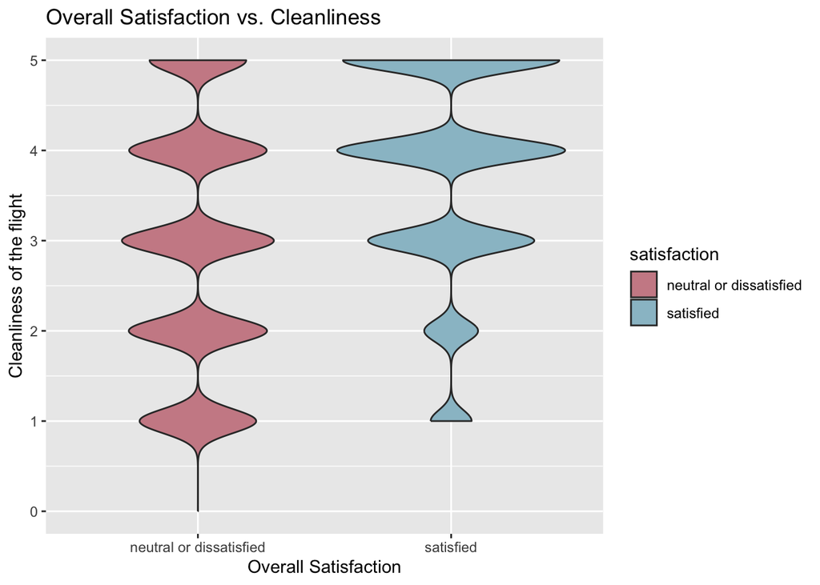

```r
ggplot(data, aes(x = satisfaction, y = Cleanliness, fill = satisfaction)) +
  geom_violin() +
  labs(title = "Overall Satisfaction vs. Cleanliness",
       x = "Overall Satisfaction",
       y = "Cleanliness of the flight")+scale_fill_manual(values = c("satisfied" = "lightblue3", "neutral or dissatisfied" = "lightpink3"))
```

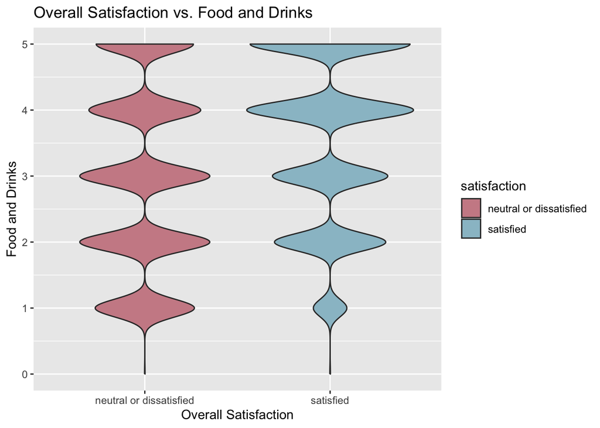

```r
ggplot(data, aes(x = satisfaction, y = Food.and.drink, fill = satisfaction)) +
  geom_violin() +
  labs(title = "Overall Satisfaction vs. Food and Drinks",
       x = "Overall Satisfaction",
       y = "Food and Drinks")+scale_fill_manual(values = c("satisfied" = "lightblue3", "neutral or dissatisfied" = "lightpink3"))
```

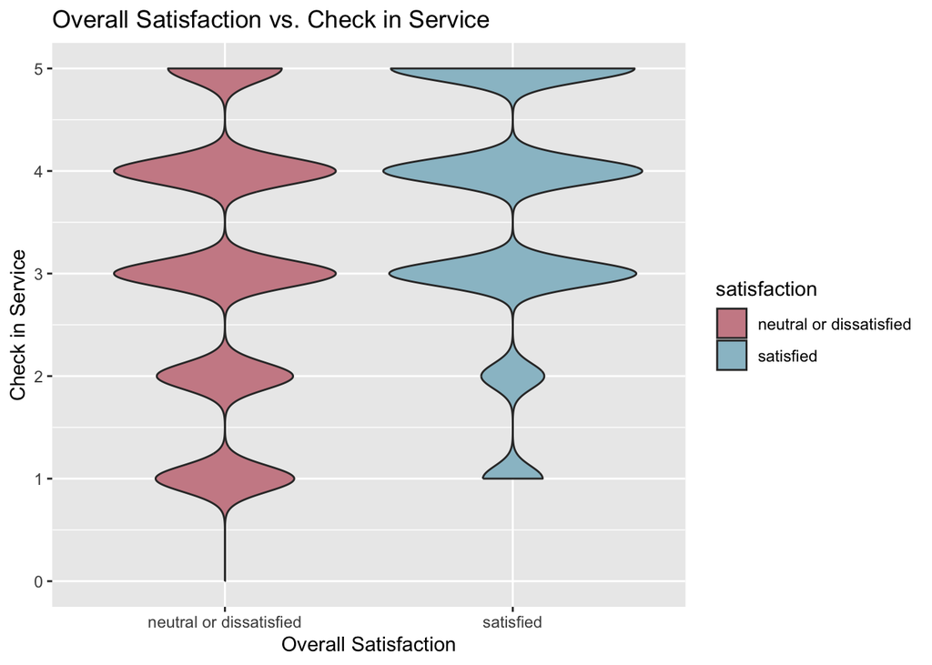

```r
ggplot(data, aes(x = satisfaction, y = Checkin.service, fill = satisfaction)) +
  geom_violin() +
  labs(title = "Overall Satisfaction vs. Check in Service",
       x = "Overall Satisfaction",
       y = "Check in Service")+scale_fill_manual(values = c("satisfied" = "lightblue3", "neutral or dissatisfied" = "lightpink3"))
```

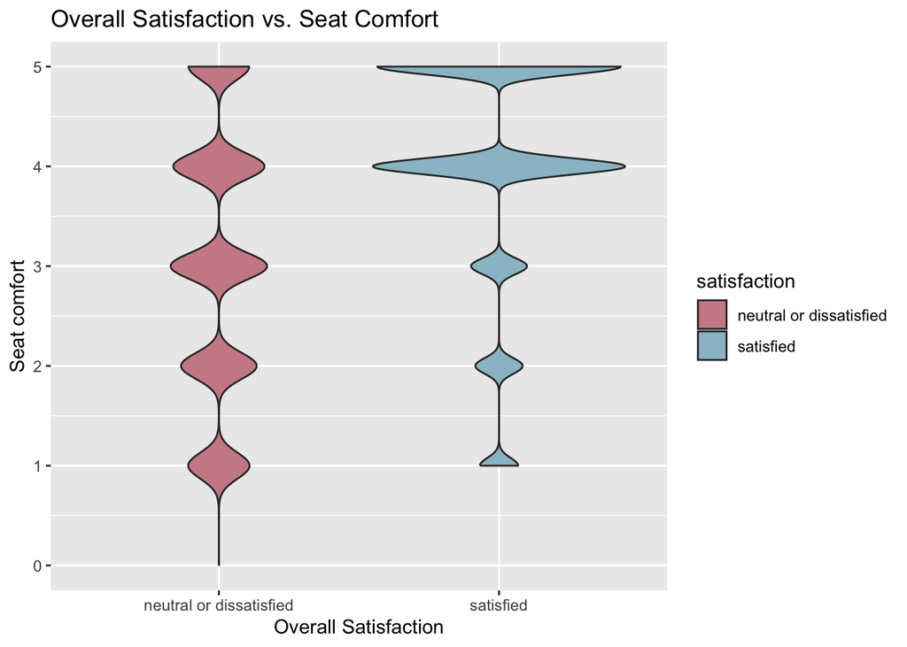

```r
ggplot(data, aes(x = satisfaction, y = Seat.comfort, fill = satisfaction)) +
  geom_violin() +
  labs(title = "Overall Satisfaction vs. Seat Comfort",
       x = "Overall Satisfaction",
       y = "Seat comfort")+scale_fill_manual(values = c("satisfied" = "lightblue3", "neutral or dissatisfied" = "lightpink3"))
```

```r
cor_Inflight <- cor(data$Inflight.entertainment, as.numeric(factor(data$satisfaction)))
print(paste("Correlation coefficient based on Overall Satisfaction and Inflight Entertainment:", cor_Inflight))
```

```
## [1] "Correlation coefficient based on Overall Satisfaction and Inflight Entertainment: 0.398059421099521"
```

```r
cor_clean <- cor(data$Cleanliness, as.numeric(factor(data$satisfaction)))
print(paste("Correlation coefficient based on Overall Satisfaction and Cleanlimess:", cor_clean))
```

```
## [1] "Correlation coefficient based on Overall Satisfaction and Cleanlimess: 0.305198011796992"
```

```r
cor_food <- cor(data$Food.and.drink, as.numeric(factor(data$satisfaction)))
print(paste("Correlation coefficient based on Overall Satisfaction and Food and Drinks:", cor_food))
```

```
## [1] "Correlation coefficient based on Overall Satisfaction and Food and Drinks: 0.209936240446408"
```

```r
cor_checkin <- cor(data$Checkin.service, as.numeric(factor(data$satisfaction)))
print(paste("Correlation coefficient based on Overall Satisfaction and Check in Service:", cor_checkin))
```

```
## [1] "Correlation coefficient based on Overall Satisfaction and Check in Service: 0.236173742841731"
```

```r
cor_seat <- cor(data$Seat.comfort, as.numeric(factor(data$satisfaction)))
print(paste("Correlation coefficient based on Overall Satisfaction and Seat Comfort:", cor_seat))
```

```
## [1] "Correlation coefficient based on Overall Satisfaction and Seat Comfort: 0.349458758136717"
```

We created `violin plots` using `ggplot()` and calculate the correlation coefficients between `Satisfaction` and different aspects of the flight experience.

We use the `geom_violin()` function in `ggplot()` to create a plot that shows the distribution of `Inflight.Entertainment` for each level of `Satisfaction`. Then we print the correlation coefficient between `Inflight.entertainment` and `satisfaction`using the `cor()` function.

We use the `geom_violin()` function in `ggplot()` to create a plot that shows the distribution of `Cleanliness` for each level of `Satisfaction`. Then we print the correlation coefficient between `Cleanliness` and `satisfaction`using the `cor()` function.

We use the `geom_violin()` function in `ggplot()` to create a plot that shows the distribution of `Food.and.drink` for each level of `Satisfaction`. Then we print the correlation coefficient between `Food.and.drink` and `satisfaction`using the `cor()` function.

We use the `geom_violin()` function in `ggplot()` to create a plot that shows the distribution of `Checkin.service` for each level of `Satisfaction`. Then we print the correlation coefficient between `Checkin.service` and `satisfaction`using the `cor()` function.

We use the `geom_violin()` function in `ggplot()` to create a plot that shows the distribution of `Seat.comfort` for each level of `Satisfaction`. Then we print the correlation coefficient between `Seat.comfort` and `satisfaction`using the `cor()` function.

## HISTOGRAM of flight distance travelled by a customer

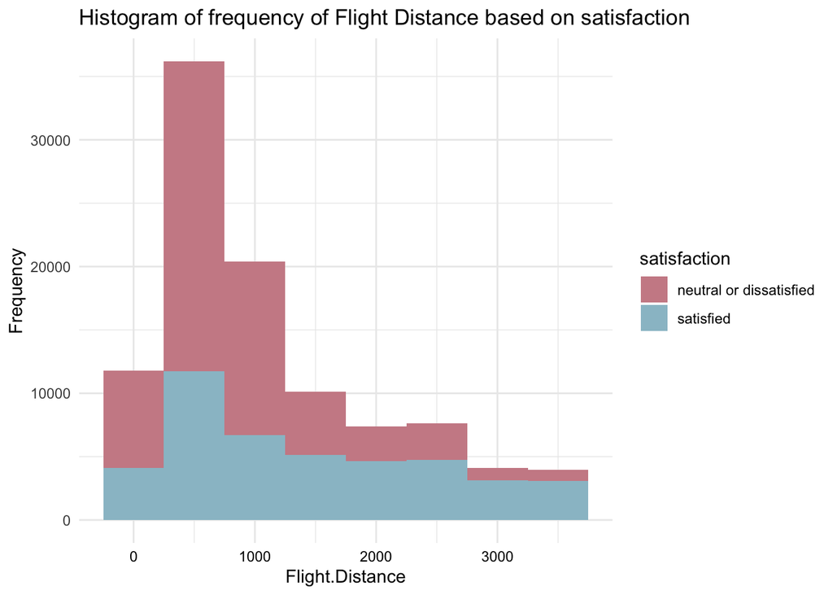

```r
ggplot(data2,aes(x=Flight.Distance,fill=satisfaction))+geom_histogram(binwidth=500)+labs(title="Histogram of frequency of Flight Distance based on satisfaction",x="Flight.Distance",y="Frequency")+theme_minimal()+ theme(
    axis.title.x = element_text(color = "black"),
    axis.title.y = element_text(color = "black"),
    plot.title = element_text(color = "black"),
    axis.text.x = element_text(color = "black"))+scale_fill_manual(values = c("satisfied" = "lightblue3", "neutral or dissatisfied" = "lightpink3"))
```

We will make a `histogram` using `ggplot()` to visualize the relationship between `satisfaction` and `Flight.Distance`.

## BOXPLOT of flight distance and customer satisfaction

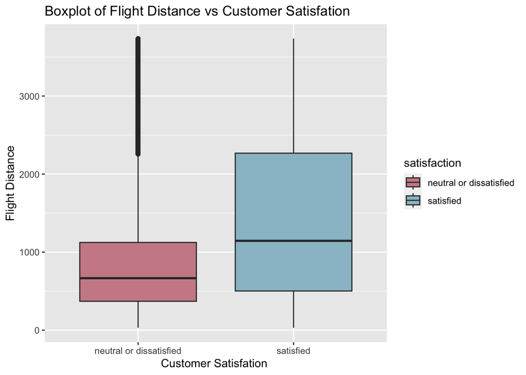

```r
ggplot(data = data2, aes(x=as.character(satisfaction ), y=Flight.Distance, fill=satisfaction)) +
    geom_boxplot() +
    labs(title="Boxplot of Flight Distance vs Customer Satisfation ", x="Customer Satisfation ", y="Flight Distance")+scale_fill_manual(values = c("satisfied" = "lightblue3", "neutral or dissatisfied" = "lightpink3"))
```

`boxplot` using `ggplot()` to visualize the relationship between `satisfaction` and `Flight.Distance`.

## Box Plot of Flight Distance by Class and Satisfaction Level

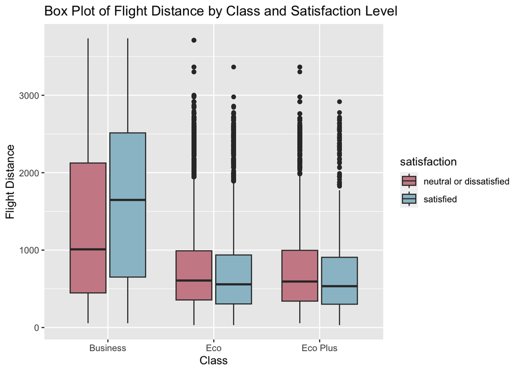

```r
ggplot(data2, aes(x = Class, y = Flight.Distance, fill = satisfaction)) +
  geom_boxplot() +
  labs(x = "Class", y = "Flight Distance", title = "Box Plot of Flight Distance by Class and Satisfaction Level") + scale_fill_manual(values = c("satisfied" = "lightblue3", "neutral or dissatisfied" = "lightpink3"))
```

## Correlation Plot of the dataset

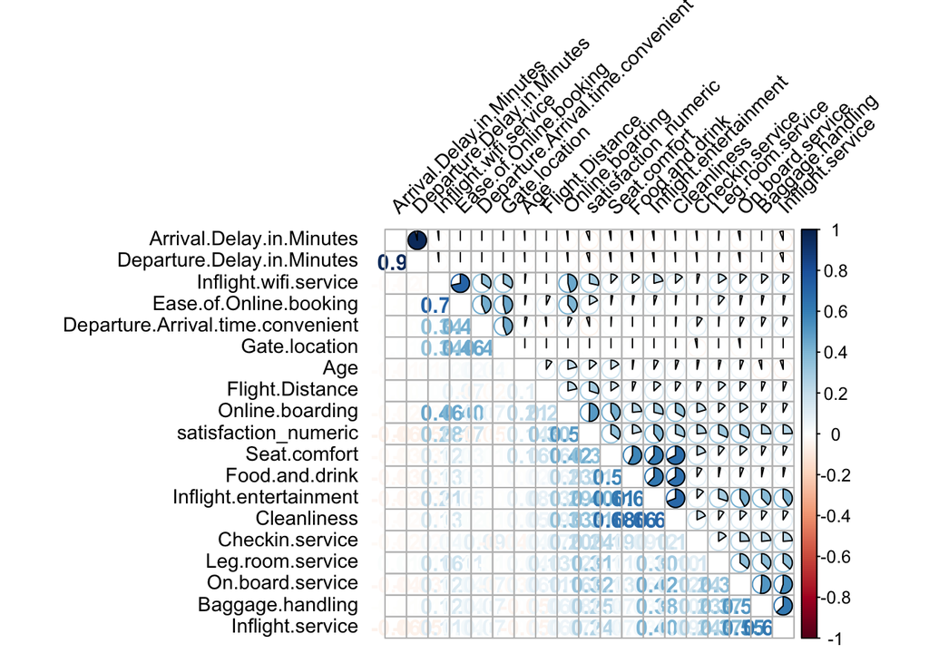

```r
library(corrplot)

data$satisfaction_numeric <- ifelse(data$satisfaction == "satisfied", 1, 0)

var_columns <- c("Flight.Distance", "Inflight.wifi.service", "Departure.Arrival.time.convenient",
                      "Ease.of.Online.booking", "Gate.location","Age", "Food.and.drink", "Online.boarding",
                      "Seat.comfort", "Inflight.entertainment", "On.board.service", "Leg.room.service",
                      "Baggage.handling", "Checkin.service", "Inflight.service", "Cleanliness","Arrival.Delay.in.Minutes","Departure.Delay.in.Minutes","satisfaction_numeric")

correlation_matrix <- cor(data[var_columns])

corrplot.mixed(correlation_matrix, tl.col = "black", tl.srt = 45,
               tl.cex = 0.9, tl.offset = 1, tl.pos = "lt", lower = 'number', upper = 'pie', order = 'hclust')
```

# Statistical Tests

## CHI-SQUARE TEST ON THREE VARIABLES

```r
alpha=0.05
ctest1 = chisq.test(data$satisfaction, data$Type.of.Travel)

ctest2 = chisq.test(data$satisfaction, data$Class)

ctest3 = chisq.test(data$satisfaction, data$Customer.Type)

ctest1
```

```
##
##  Pearson's Chi-squared test with Yates' continuity correction
##
## data:  data$satisfaction and data$Type.of.Travel
## X-squared = 20945, df = 1, p-value <2e-16
```

```r
ctest2
```

```
##
##  Pearson's Chi-squared test
##
## data:  data$satisfaction and data$Class
## X-squared = 26472, df = 2, p-value <2e-16
```

```r
ctest3
```

```
##
##  Pearson's Chi-squared test with Yates' continuity correction
##
## data:  data$satisfaction and data$Customer.Type
## X-squared = 3657, df = 1, p-value <2e-16
```

We have conducted `chisq.test()` to find the $\chi^2$ analysis on three variables - `Type.of.Travel`, `Class`, `Customer.Type`.

Analysis is as follows:

Null Hypothesis ($H_{0}$): There is no significant association between `Satisfaction` and `Type.of.Travel`, `Class`, `Customer.Type`, respectively.

Alternative Hypothesis($H_{A}$): There is a significant association between `Satisfaction` and `Type.of.Travel`, `Class`, `Customer.Type`, respectively.

The `p-value` returned by the $\chi^2$ test in comparison of satisfaction and `Type.of.Travel` is $0$ then satisfaction and `Class` is $0$ and finally satisfaction and `Customer.Type` is $0$, which are less than the standard $\alpha$=0.05. As a result, the null hypothesis is rejected, and the alternate hypothesis is accepted. We may draw the conclusion that there is significant association between `Satisfaction` and `Type.of.Travel`, `Class`, `Customer.Type`, respectively.

## T-test on `age` variable

```r
a<-t.test(Age~satisfaction,data = data)
a
```

```
##
##  Welch Two Sample t-test
##
## data:  Age by satisfaction
## t = -46, df = 1e+05, p-value <2e-16
## alternative hypothesis: true difference in means between group neutral or dissatisfied and group satisfied is not equal to 0
## 95 percent confidence interval:
##  -4.36 -4.01
## sample estimates:
## mean in group neutral or dissatisfied               mean in group satisfied
##                                  37.6                                  41.8
```

```r
a$p.value
```

```
## [1] 0
```

We performed a T-Test using the `t.test()` function and it can be observed that the means of the neutral/dissatisfied and satisfied are different with respective values of 37.6 and 41.8. The `p-value` of $0$ is less than $\alpha$=0.05 which indicates that the dissatisfied/neutral and satisfied customers have different age groups

## Anova test on age category and satisfaction

```r
model<-aov(Age.cat2 ~ satisfaction,data=data)
ezids::xkabledply(model,title="Anova test result of Age and Satisfaction")
```

Anova test result of Age and Satisfaction

|  | Df | Sum Sq | Mean Sq | F value | Pr(>F) |
| --- | --- | --- | --- | --- | --- |
| satisfaction | 1 | 1854 | 1854.369 | 4254 | 0 |
| Residuals | 103902 | 45289 | 0.436 | NA | NA |

We performed an ANOVA test on satisfaction and age category using `aov()` function. We found that the p value is $0$ is lower than $\alpha$=0.05, which means we can reject the null hypothesis of that satisfaction of customer staying the same around each age category (“Under 20”, “20-40”, “40-80”, and “above 80”). The means of satisfaction scores for each of these age groups are compared using the ANOVA test to see if there are any statistically significant differences.

## T test on arrival and departure delay

```r
b<-t.test(data4$Arrival.Delay.in.Minutes,data4$Departure.Delay.in.Minutes)
print(b)
```

```
##
##  Welch Two Sample t-test
##
## data:  data4$Arrival.Delay.in.Minutes and data4$Departure.Delay.in.Minutes
## t = 12, df = 2e+05, p-value <2e-16
## alternative hypothesis: true difference in means is not equal to 0
## 95 percent confidence interval:
##  0.357 0.493
## sample estimates:
## mean of x mean of y
##      4.15      3.72
```

Analysis is as follows: Null Hypothesis($H_{0}$): The mean of departure and arrival delay time are same

Alternative Hypothesis($H_{A}$): The mean of departure and arrival delay time are different

The `p-value` returned by comparing arrival delay and departure delay is $9.858\times 10^{-35}$ which is lower than $\alpha$=0.05. Thus, we can reject the null hypothesis and say departure and arrival delay time are different.

## T-test on arrival and departure delay and satifaction

```r
b1<-t.test(Arrival.Delay.in.Minutes~satisfaction,data = data4)
b2<-t.test(Departure.Delay.in.Minutes~satisfaction,data = data4)


print(b1)
```

```
##
##  Welch Two Sample t-test
##
## data:  Arrival.Delay.in.Minutes by satisfaction
## t = 27, df = 89411, p-value <2e-16
## alternative hypothesis: true difference in means between group neutral or dissatisfied and group satisfied is not equal to 0
## 95 percent confidence interval:
##  1.24 1.44
## sample estimates:
## mean in group neutral or dissatisfied               mean in group satisfied
##                                  4.74                                  3.40
```

```r
print(b2)
```

```
##
##  Welch Two Sample t-test
##
## data:  Departure.Delay.in.Minutes by satisfaction
## t = 15, df = 88147, p-value <2e-16
## alternative hypothesis: true difference in means between group neutral or dissatisfied and group satisfied is not equal to 0
## 95 percent confidence interval:
##  0.591 0.775
## sample estimates:
## mean in group neutral or dissatisfied               mean in group satisfied
##                                  4.03                                  3.34
```

We first conducted an independent t-test using the `t.test()` function to determine if the two variables `Arrival.Delay.in.Minutes` and `Departure.Delay.in.Minutes` have similar means.

Analysis is as follows: Null Hypothesis($H_{0}$): The mean of departure and arrival delay time is the same across all levels of satisfaction.

Alternative Hypothesis($H_{A}$): The mean of departure and arrival delay time is different for at least one pair of satisfaction levels.

The `p-value` returned for arrival delay by the $t-test$ is $4.604\times 10^{-159}$ and for departure delay by the $t-test$ is $7.807\times 10^{-48}$. As a result, the null hypothesis is rejected, and the alternate hypothesis is accepted. We draw the conclusion that the mean is different for at least one pair of satisfaction levels.

## CHI-SQUARE TEST on satisfaction and inflight details

```r
ctest1 = chisq.test(data$satisfaction, data$Inflight.entertainment)
ctest2 = chisq.test(data$satisfaction, data$Cleanliness)
ctest3 = chisq.test(data$satisfaction, data$Food.and.drink)
ctest4 = chisq.test(data$satisfaction, data$Seat.comfort)

print(ctest1)
```

```
##
##  Pearson's Chi-squared test
##
## data:  data$satisfaction and data$Inflight.entertainment
## X-squared = 18508, df = 5, p-value <2e-16
```

```r
print(ctest2)
```

```
##
##  Pearson's Chi-squared test
##
## data:  data$satisfaction and data$Cleanliness
## X-squared = 10245, df = 5, p-value <2e-16
```

```r
print(ctest3)
```

```
##
##  Pearson's Chi-squared test
##
## data:  data$satisfaction and data$Food.and.drink
## X-squared = 5203, df = 5, p-value <2e-16
```

```r
print(ctest4)
```

```
##
##  Pearson's Chi-squared test
##
## data:  data$satisfaction and data$Seat.comfort
## X-squared = 15756, df = 5, p-value <2e-16
```

We have conducted `chisq.test` to find the $\chi^2$ on four variables - `Inflight.entertainment`, `Cleanliness`, `Food.and.drink`, `Seat.comfort`.

Analysis is as follows:

Null Hypothesis($H_{0}$): There is no significant association between `Satisfaction` and `Inflight.entertainment`, `Cleanliness`, `Food.and.drink`, `Seat.comfort` respectively.

Alternative Hypothesis($H_{A}$): There is a significant association between `Satisfaction` and `Inflight.entertainment`, `Cleanliness`, `Food.and.drink`, `Seat.comfort` respectively.

The `p-value` returned by the $\chi^2$ test on `Inflight.entertainment`, `Cleanliness`, `Food.and.drink`, `Seat.comfort` is `p-value` of $0$, $0$, $0$, $0$ which are lesser than $\alpha$=0.05 respectively. As a result, the null hypothesis is rejected, and the alternate hypothesis is accepted. We may draw the conclusion that there is significant association between `Satisfaction` and `Inflight.entertainment`, `Cleanliness`, `Food.and.drink`, `Seat.comfort` respectively.

## T test on flight distance and satisfaction

```r
k<-t.test(Flight.Distance~satisfaction,data = data)
```

We first conducted an independent t-test using the `t.test()` function to determine if the two variables `Flight.Distance` and `satisfcation` have similar means. Analysis is as follows:

Null Hypothesis($H_{0}$): The mean flight distance is the same across all levels of satisfaction

Alternative Hypothesis($H_{A}$): The mean flight distance is different for at least one pair of satisfaction levels.